# Una anàlisi del Servei d’Atenció a Domicili al Vallès Oriental

mapes anàlisi de dades

Aquesta anàlisi incorpora mètodes multivariants i un mapa.

Albert Valls Garcia https://twitter.com/AlbertVallsG1  
2022-04-21

L’edat no perdona i fins i tot, quan som joves el cos ens traeix i deixa de fer cas a la nostra voluntat. Podem perdre autonomia física, mental i sensorial que ens impedeix fer actes simples i quotidians, com cuinar, anar a comprar, caminar, menjar, etc. Quan això passa es diu que esdevenim dependents. Fer front a aquesta realitat no sempre és fàcil en el context econòmic, polític i social que vivim i que és ple de grans reptes als quals cal distribuir una atenció pública limitada.

Tradicionalment, aquesta situació s’ha resolt a través de les cures de la família envers aquells membres que han esdevingut dependents. Tanmateix, les famílies tenen configuracions diverses que obren la possibilitat al fet que molts membres que puguin esdevenir dependents, no tinguin l’alternativa de tenir una atenció perquè els potencials cuidadors són parents llunyans, treballadors o tenen altres ocupacions prioritàries, entre d’altres.

Des de l’aparició de l’estat i les administracions públiques, s’han cercat diverses solucions. Per exemple, s’ha procurat que altres membres de la societat tinguin cura d’aquelles persones que per diversos motius, afronten una situació de dependència. Una segona opció ha consistit en donar una compensació als familiars d’una persona dependent que hagin esdevingut cuidadors del seu familiar. Aquestes solucions, que poden derivar en serveis o ajuts públics, generen riscos i costos econòmics que col·lectivament cal afrontar.

Actualment, podríem dir que la dependència no és un tema que aparegui sovint als mitjans de comunicació o a les xarxes socials, però entre els anys setanta i el 2006, les cures de llarga durada i l’atenció a la dependència sí que van tenir una presència destacada a l’agenda pública. De fet, és l’època en la qual es configura el sistema de cures de llarga durada (CLD) que tenim des de 2006 i del qual, el Servei d’Atenció a Domicili (SAD) en forma part.

En aquest article, he volgut estudiar preliminarment quines són les variables sociodemogràfiques que expliquen el canvi en el nombre d’usuaris del SAD i analitzar com varien els usuaris del SAD en funció d’aquelles variables que l’expliquen a la comarca del Vallès Oriental.

Per fer això, faig servir tècniques de recerca multivariants mentre ofereixo un conjunt de mapes de la comarca on es visualitzen les distribucions als municipis de les variables sociodemogràfiques estudiades. Abans d’oferir aquest anàlisi, faig una breu descripció de l’esmentat sistema de CLD implantat des del 2006 i del qual el SAD en forma part. També hi ha una menció a la legislació catalana posterior, perquè les dues lleis diferencien la gestió i el finançament del SAD. Fent tot això, espero retornar els afers de cures de llarga durada com el SAD al radar públic. Perquè com veurem, hi ha autors que afirmen que la universalització de serveis d’aquest tipus encara no s’ha assolit, tot i que ha millorat força.

L’anàlisi se centra en el servei del SAD pel fet que he estat jove en pràctiques al Consell Comarcal del Vallès Oriental (CCVOR) i la meva tasca ha estat analitzar les dades del SAD de la comarca. Els fitxers rebuts i treballats es corresponen amb les dades del SAD dels municipis de l’Àrea Bàsica de Serveis Socials del Vallès Oriental – Resta del Vallès Oriental (ABSSVOR – Resta del VOR). Per més informació sobre les ABSS, veure l’article 34 de la llei 12/2007.

Pel catedràtic Vicenç Navarro, el debat sobre la dependència anterior al 2006 es va correspondre en desenvolupar el quart pilar de l’estat del benestar a Espanya i complementar els altres tres: el dret a la sanitat, el dret a l’educació i el dret a la jubilació. Aquest catedràtic ha explicat que va assessorar a membres del PSOE sobre el desenvolupament d’aquest quart pilar. Quan el PSOE va tornar a assolir el govern, Vicenç Navarro fa èmfasi en el fet que el govern del president José Luís Rodríguez Zapatero es va centrar exclusivament en el desenvolupament dels serveis domiciliaris tot menystenint l’impuls de les escoles bressol. Mentrestant, l’equip econòmic del president aplicava polítiques d’austeritat (Navarro, 2020).

Segons Rodríguez Cabrero i Marbán Gallego a l’estat Espanyol, el debat sobre la dependència es va caracteritzar per la interacció entre l’estat, el mercat, la família i la societat civil en mig de canvis de governs i canvis sociodemogràfics. Especialment, l’envelliment de la població, canvis en la funció de la família i la integració laboral de la dona. Durant el debat hi va haver una tensió latent entre els següents punts de gravetat; assolir un model de servei universal o assolir un model de caràcter assistencial per contenir la despesa del servei (Rodríguez Cabrero & Marbán Gallego, 2016).

La culminació del sistema de CLD el trobem amb l’aprovació de la llei 39/2006, de 14 de desembre, de Promoció de l’Autonomia Personal i Atenció a les Persones en Situació de Dependència (LAPAD) i el desenvolupament del Sistema Espanyol d’Autonomia i Dependència (SAAD). Posteriorment, a Catalunya es va aprovar la llei 12/2007 de serveis socials, que va introduir les ABSS i el professional de referència. En relació al SAD, les dues lleis han establert diferències de modalitats en l’aprovisionament, la gestió i finançament a Catalunya: SAD Social i SAD Dependència.

Segons Rodríguez Cabrero, la LAPAD és una combinació amb major o menor mesura dels següents elements (Rodríguez Cabrero, 2007):

- Universalisme creixent, però limitat.
- Extensió i intensificació de la responsabilitat familiar.
- Gestió descentralitzada.
- Suport en el sector privat: això ha comportat que empreses i el tercer sector proveeixin serveis públics.
- Importància de la persona afectada o usuari i el seu dret a escollir la prestació adequada a les seves necessitats.

Juntament amb Marbán Gallego també explica que l’actual sistema de resposta a la dependència, el risc es comparteix entre diversos agents institucionals i socials mentre es garanteix una cobertura universal de prestacions bàsiques topades; es gestiona de manera descentralitzada; i la provisió de serveis és mixta en un marc creixent de competència entre els sectors mercantils i el Tercer Sector (Rodríguez Cabrero & Marbán Gallego, 2016). Per tant, serveis com el SAD acostumen estar externalitzats.

Respecte a l’èxit o fracàs del sistema establert des de 2006, Aguilar-Hendirckson argumenta que no hi ha una resposta concreta sinó que depèn de certs paràmetres d’avaluació. Si es pren al peu de la lletra els objectius i el discurs de la llei (màxima universalització), és fàcil concloure que ha fracassat perquè no s’ha assolit. A més, encara hi ha moltes queixes sobre la qualitat del servei (Aguilar-Hendirckson, 2020).

En qualsevol cas, aquest autor considera que la reforma va ser parcialment exitosa. El govern central, sense tenir gaire en compte els ens autonòmics i locals, va regular i estructurar un sistema de serveis de cures i atencions socials que anteriorment eren gairebé residuals (Aguilar-Hendirckson, 2020).

Malgrat la posterior descentralització i fragmentació del sistema CLD a les autonomies i ens locals, es va contribuir a oferir serveis socials, com el Servei d’Atenció a Domicili (SAD), a una creixent part de la població (Aguilar-Hendirckson, 2020). Segons aquest autor, encara no hi ha plena universalització, tot i que la provisió i l’accés al servei ha millorat.

Per mesurar la universalització dels serveis de CLD, la qüestió fonamental per respondre és quina part de la població que és dependent té o no té accés als serveis de CLD i quina quantitat de població dependent en fa ús actualment.

Aquesta qüestió no la intento resoldre però n’ofereixo una aproximació des d’altres paràmetres. Mitjançant el llenguatge de programació en R, he transformat els fitxers proporcionats pel CCVOR. He contat quantes persones usuàries del SAD hi ha a cada municipi (casos) i quantes hores se’ls hi ha dedicat conjuntament de manera anual per un període de deu anys que compren des del 2011 a 2020.

He incorporat a l’anàlisi aquelles variables que després de lectures sobre la dependència i les CLD m’han semblat que poden tenir una estreta relació amb el SAD. Per això, he inclòs variables poblacionals, de salut o de pobresa. Així com també, el llindar de pobresa, l’esperança de vida, o els anys de vida saludables. Un cop incorporades, mitjançant una matriu de correlacions he determinat quines estan correlacionades amb les variables del SAD al Vallès Oriental i les he analitzat més profundament.

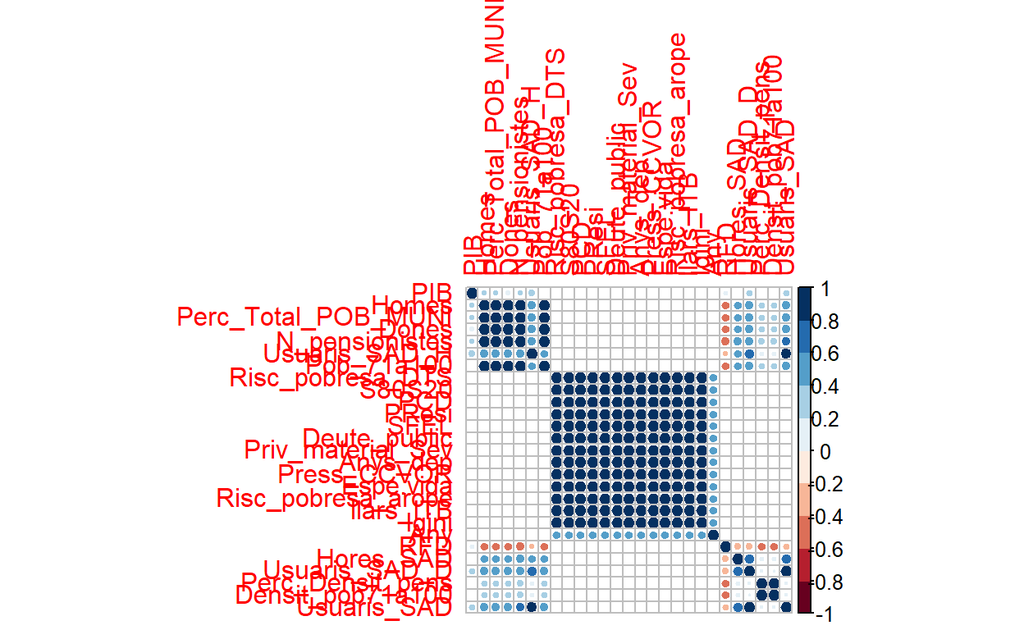

Segons la matriu de correlacions, les variables poblacionals, com la població de 71 a 100 anys, el nombre de pensionistes i la Renda Familiar Disponible (RFD) estan correlacionades amb els usuaris del SAD. Les variables relacionades amb la pobresa, els anys de dependència i l’esperança de vida no estan correlacionades amb els usuaris del SAD. Per això, no les he estudiat més profundament.

Dit això, faig un breu incís demogràfic sobre el Vallès Oriental. En efecte, la comarca no s’escapa de les tendències sociodemogràfiques esmentades i és cert que la població s’està envellint.

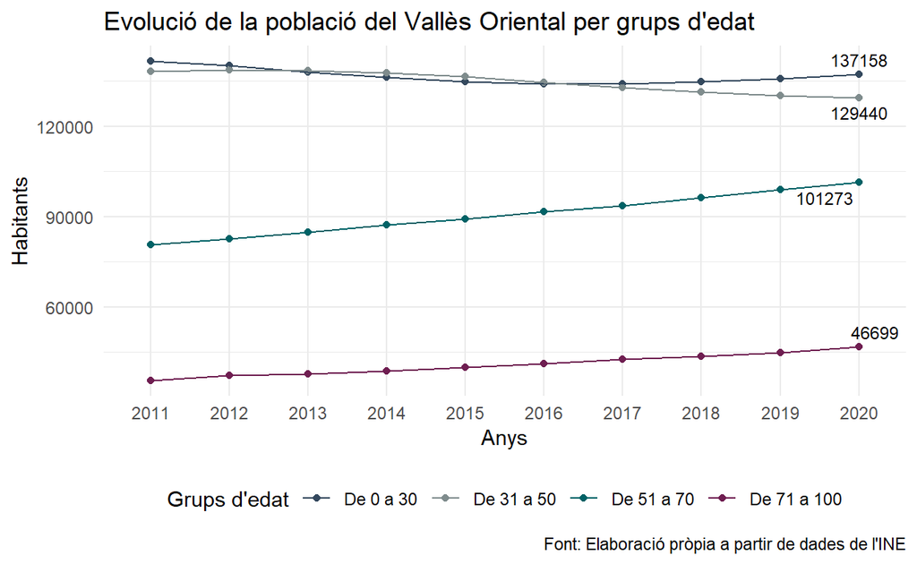

Els grups d’edat d’entre 51 i 70 anys i de 71 a 100 anys augmenten progressivament a mesura que passen els anys. L’esperança de vida de les dones a la província de Barcelona és de 86 anys i la dels homes de 80 anys. Els anys estimats de dependència de la gent gran a la província de Barcelona, resultat de restar l’esperança de vida amb els anys de vida saludable després dels seixanta-cinc anys; pel que fa a les dones és de 4,7 anys de mitjana i pels homes de 3,5 anys de mitjana. Pel que fa a les dades del SAD de l’ABSSVOR – Resta del VOR, durant el període estudiat hi ha hagut més del doble de persones usuàries que eren dones respecte als homes. D’aquesta manera, a les persones usuàries que eren dones, també han rebut moltes més hores que els homes.

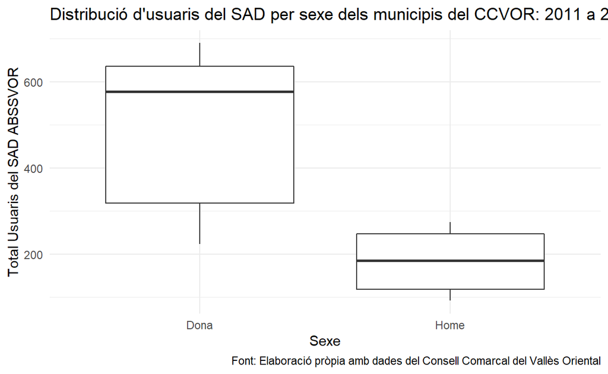

Tot i això, hi ha hagut anys en els quals les persones usuàries que eren homes rebien de mitjana més hores de servei SAD que les persones usuàries que eren dones al Vallès Oriental. Això pot ser causat pel fet que els homes, malgrat tenir un període més breu de dependència, aquest és més intens que el de les dones.

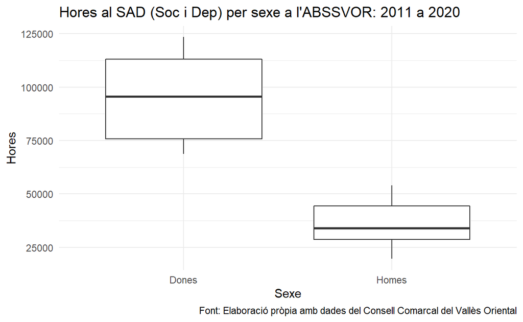

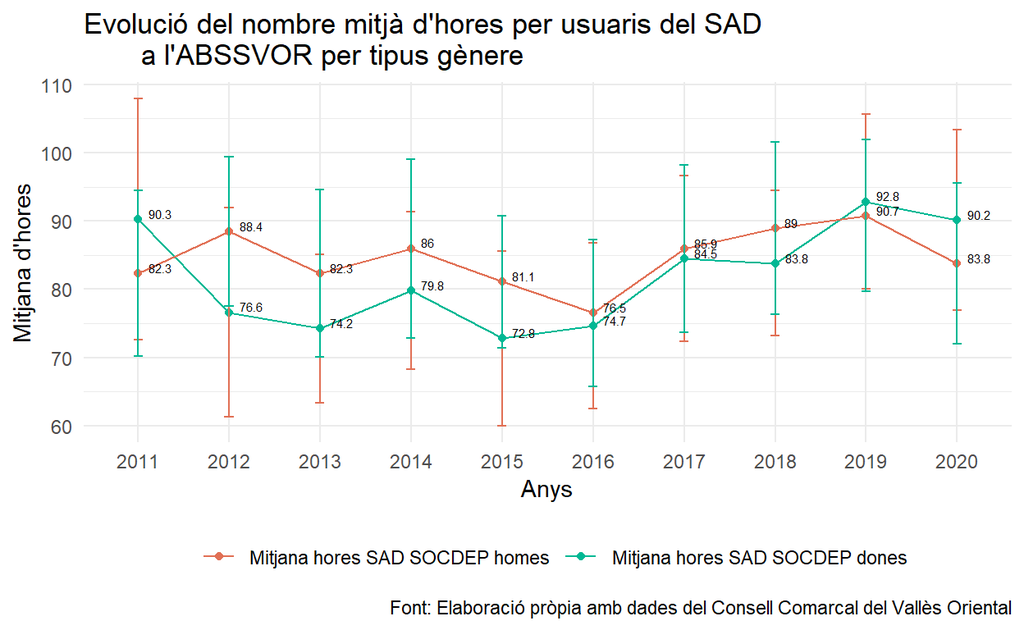

Els mètodes de recerca multivariants emprats indiquen que de manera indirecta, la renda familiar disponible (RFD) per habitant té un efecte sobre els usuaris del SAD a través de la població (envellida o pensionistes). A més, he analitzat com varien els usuaris del SAD en funció de canvis en la RFD al Vallès Oriental. L’any 2014 hi va haver un augment brusc de la RFD per habitant al Vallès Oriental i he volgut veure com això ha afectat la variació dels usuaris del SAD a la comarca.

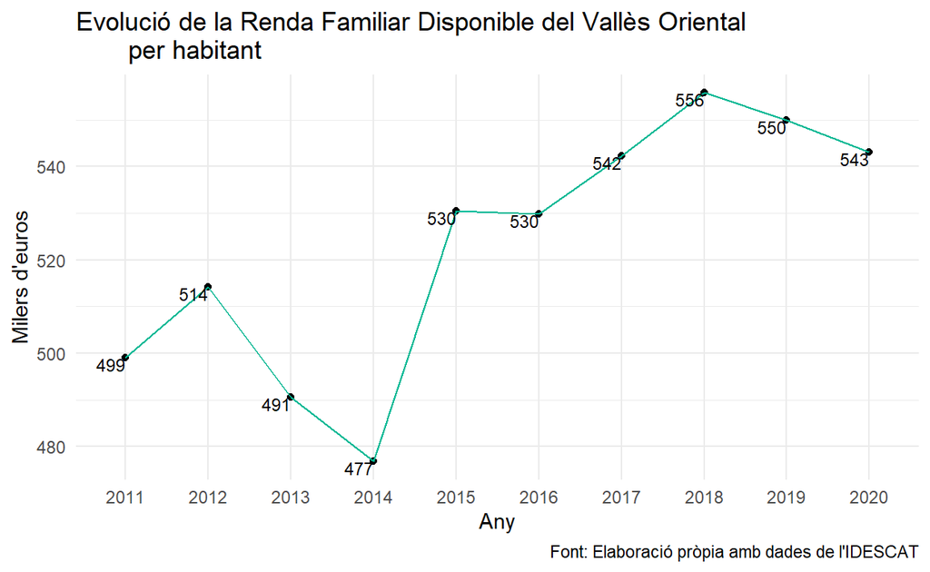

Per això he generat dos grups de municipis del Vallès Oriental. Un grup de municipis amb menys població envellida i un grup de municipis amb més població envellida. Un cop fet això, els comparo abans i després del canvi en la RFD de l’any 2014.

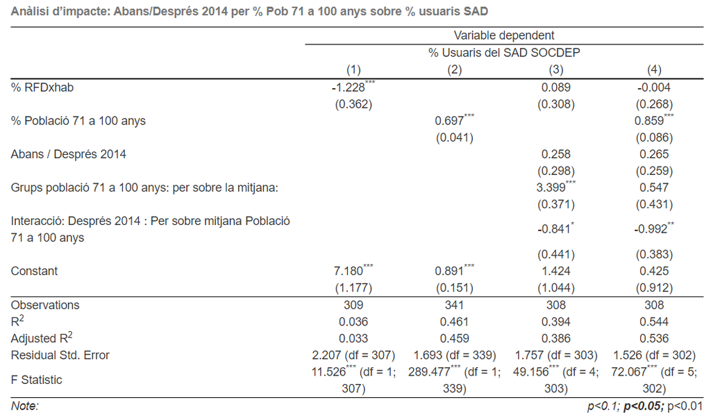

Font: Elaboració pròpia amb dades del Consell Comarcal del Vallès Oriental i de l’ICGC

Abans d’analitzar aquesta taula, cal comentar que aquest és un experiment descontrolat perquè els increments de RFD per habitant al Vallès Oriental afecta tant al grup de municipis del Vallès Oriental amb més població envellida com el grup amb menys població envellida. No tenim control sobre l’increment de la RFD del 2014 a la comarca, perquè no va ser una intervenció pública premeditada.

Per tant, la interacció no ens dirà que hagués passat en el grup de “control” si no hi hagués hagut un augment de RFD per habitant l’any 2014 en un grup de tractament, com si empréssim el mètode de les dobles diferències. Si no que ens dirà com varien els usuaris del SAD a municipis amb més i menys població envellida en funció d’un canvi en la RFD sense tenir en compte altres variables.

Fet aquest aclariment, interpretem la interacció de la taula anterior del quart model: si la variable “abans després de 2014” pren el valor “després 2014”, l’impacte de la variable “abans després de 2014” quan pren el valor “abans” sobre el nombre d’usuaris del SAD als municipis del Vallès Oriental, es redueix de potència en un 0.99% per als municipis amb més població envellida (per sobre de la mitjana de població envellida).

És a dir que els municipis per sobre de la mitjana de població envellida van reduir els seus usuaris del SAD després de l’augment de RFD per habitant. Per altra banda, els municipis per sota de la mitjana de població de 71 a 100 anys del Vallès Oriental, van augmentar els seus usuaris del SAD.

En altres paraules, no podem inferir l’efecte causal dels augments de la RFD per habitant sobre els usuaris del SAD. Però si podem observar que els municipis amb menys i més població de gent gran varien el seu nombre d’usuaris del SAD quan hi ha un canvi en la RFD per habitant al Vallès Oriental. A continuació, veiem les tendències dels dos grups de municipis establerts.

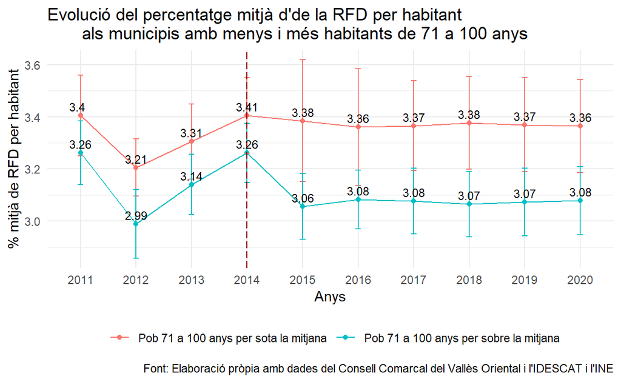

Aquesta paradoxa també la podem observar als mapes de la comarca. Només per fer els mapes sobre el SAD de la comarca he inclòs a les dades de l’ABSSVOR – Resta del VOR les observacions de Mollet del Vallès i Granollers per l’any 2019. Les he extret del portal de dades obertes de la Generalitat. Malgrat que el servei del SAD està ofert a qualsevol persona dependent o amb una necessitat social justificada sense tenir en compte l’edat, no és cap secret que la majoria de persones usuàries o dependents són persones d’edat avançada. Aleshores, he localitzat on es concentrava la població envellida i les persones usuàries del SAD l’any 2019:

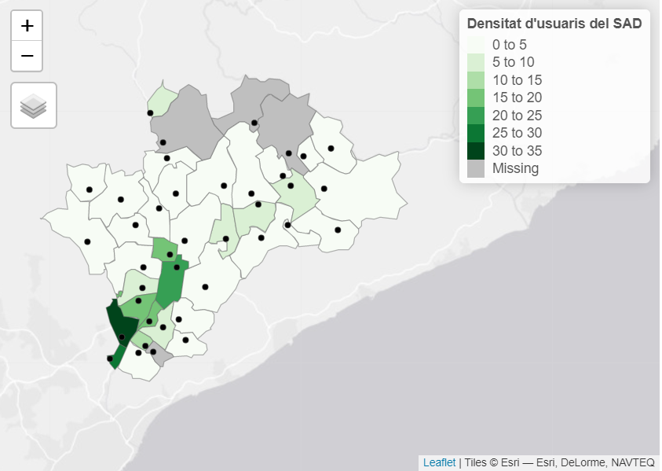

Font: Elaboració pròpia amb dades del Consell Comarcal del Vallès Oriental i de l’ICGC

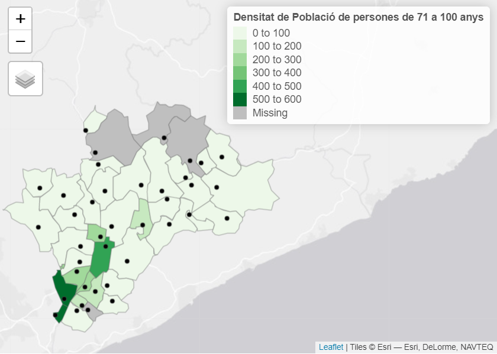

Font: Elaboració pròpia amb dades de l’INE i de l’ICGC

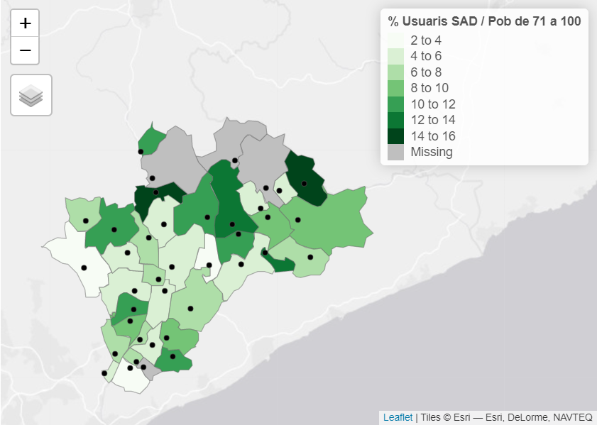

Font: Elaboració pròpia amb dades de l’INE, del Consell Comarcal del Vallès Oriental i l’ICGC

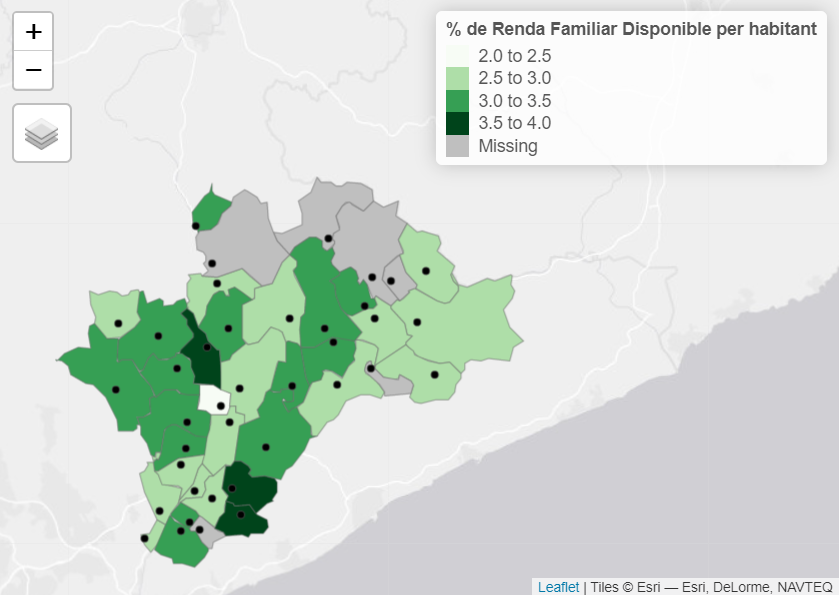

Font: Elaboració pròpia amb dades de l’IDESCAT i l’ICGC

Amb les dues primeres imatges del Vallès Oriental, podem veure com la majoria de les persones usuàries del SAD i la majoria de la població envellida es concentra a les zones més urbanes de la comarca (entre Granollers i Mollet del Vallès). Tot seguit comparem el percentatge d’usuaris del SAD d’un municipi amb el percentatge de població de 71 a 100 anys del mateix municipi i la distribució de la RFD per habitant a la comarca.

# Mapa del SAD al Vallès Oriental: 2019

[interactive chart not shown]

Podem observar que allà on hi ha un percentatge més alt d’usuaris del SAD respecte al grup d’edat d’entre 71 i 100 anys de la població del mateix municipi, no es correspon amb les zones més urbanes. Només a Gualba i Figaró-Montmany, els seus usuaris del SAD representen una mica més del 15% de la població d’entre 71 i 100 anys dels respectius municipis. Pel que fa a la distribució de la RFD (2018) per habitant (2019) al Vallès Oriental (l’IDESCAT no ha actualitzat les dades de la RFD en el moment de fer aquest treball), podem copsar que els municipis més poblats no tenen una RFD alta.

No obstant això, en els seus treballs, Rodríguez Cabrero i Marbán Gallego emfatitzen que s’ha produït un cert desplaçament del sector no lucratiu, o economia social, pel sector mercantil allà on existeixen marges de rendibilitat, alhora que el sector no lucratiu tendeix a concentrar-se en els col·lectius més vulnerables i en els àmbits de menor economia d’escala (Rodríguez Cabrero & Marbán Gallego, 2016).

Tanmateix, hi ha fonts del CCVOR que destaquen que els marges de beneficis són petits pel fet que és necessari fer moltes hores de servei per generar-los. Visualitzant els mapes podem pensar que allà on hi ha més potencial per fer més hores és a les zones urbanes, on hi ha més població envellida, però també són zones on hi ha menys RFD per habitant en comparació a altres municipis amb menys població envellida.

Per validar el clam d’aquest autors, caldria un estudi a la comarca del Vallès Oriental per determinar si les entitats del tercer sector concentren els seus usuaris a municipis amb més població envellida però amb menys renda per habitant mentre s’avalua també, si les empreses privades concentren els seus usuaris als municipis amb menys població envellida amb més RFD per habitant.

Un cop analitzat el servei del SAD al Vallès Oriental, complim amb l’objectiu de tornar a posar un dels serveis del quart pilar de l’estat del benestar al radar públic. Hi ha tres elements a destacar pel fet d’haver cercat quines variables sociodemogràfiques afecten els usuaris del SAD i com el seu nombre varia segons les variacions de les mateixes.

Primer, la RFD per habitant té un efecte sobre els usuaris del SAD a través de la població envellida (relació indirecta). Segon, després de l’augment de la RFD per habitant al Vallès Oriental l’any 2014, els municipis de l’ABSSVOR – Resta del VOR amb més població envellida van reduir els seus usuaris del SAD mentre que aquells municipis amb menys població envellida els van augmentar. Tercer, assumint que bona part de la població envellida és majoritària en el conjunt d’usuaris de serveis com el SAD, els mapes ens diuen que la gestió del servei és una circumstància social molt urbana. També ens diuen que el servei a determinats municipis cobreix relativament a més població envellida que a les zones més urbanes i amb més població envellida.

Dit això, el futur del servei del SAD encara té molt recorregut per fer i dependrà de la correlació de forces polítiques als ens locals. Aquest ens, són una peça clau per expandir la universalització del servei del SAD. En aquesta línia, actualment Vicenç Navarro insisteix en tres propostes clau: Primer, un canvi d’actitud de l’home, que ha de ser corresponsable de la tasca familiar. Segon aprofundir molt més amb la integració de la dona al mercat laboral i tercer, facilitar la immigració per incorporar-la a la provisió de serveis públics (Navarro, 2020).

### Bibliografia

Aguilar-Hendirckson, M. (2020). Long-term care in Spain: a reform failure or regulation of a development path? International Journal of Sociology and Social Policy.

Navarro, V. (2020). El quart pilar del benestar: alliberar les dones i salvar les pensions. Públic. https://blogs.publico.es/pensament-critic/2020/01/23/el-quart-pilar-del-benestar-alliberar-les-dones-i-salvar-les-pensions/

Rodríguez Cabrero, G. (2007). La protección social de la dependencia en españa: un modelo sui generis de desarrollo de derechos sociales. Política y sociedad, 69-85.

Rodríguez Cabrero, G., & Marbán Gallego, V. (2016). La atención a la dependencia en perspectiva europea: de la assistencialización a la cuasi-universalización. En E. del Pino, & M. Rubio Lara, Los estados del bienestar en la encrucijada: políticas sociales en perspectiva comparada (págs. 314-338). Madrid: Tecnos.

Enllaços a les fonts de dades obertes

Codis del Vallès Oriental https://www.idescat.cat/codis/?id=50&n=10&lang=es Altitud, superfície i població. Municipis https://www.idescat.cat/pub/?id=aec&n=925 Dades obertes https://analisi.transparenciacatalunya.cat/ca/

SAD https://analisi.transparenciacatalunya.cat/Societat-benestar/Servei-d-Ajuda-a-Domicili-SAD-/qvkp-qkzs

IRPF https://analisi.transparenciacatalunya.cat/Hisenda/Impost-sobre-la-renda-de-les-persones-f-siques/8i54-wzrf

https://www.idescat.cat/pub/?id=irpf&n=4070&by=mun&t=201800 Pensions https://analisi.transparenciacatalunya.cat/Societat-benestar/Estad-stica-de-pensions-contributives/pxkv-pz2p

https://www.idescat.cat/pub/?id=pens&n=10966&by=mun&t=201100 https://www.lamoncloa.gob.es/serviciosdeprensa/notasprensa/inclusion/Paginas/2021/261021-gasto_pensiones.aspx

https://w6.seg-social.es/ProsaInternetAnonimo/OnlineAccess;jsessionid=0000GbwC64WixDoCh6hdjlFdkKG:18jahgojj?ARQ.SPM.TICKET=66cb31e263de46f7a2a419554d0aa00a&SPM.CONTEXT=internet&ARQ.SPM.TMS_NAVEGACION=1643967733920 RFD – Renda familiar disponible per municipis índex: https://www.idescat.cat/pub/?id=rfdbc&n=13301&l%20ang=es&by=mun Població i superfície: https://www.idescat.cat/pub/?id=aec&n=925&lang=es Sector públic de la Generalitat. Despès pressupost per àrees polítiques de despesa: https://www.idescat.cat/pub/?id=aec&n=683&lang=es&t=2017 Altres variables econòmiques: Producció de béns públics de caràcter social

Suport financer als ens locals

Deute públic

Ingressos Consell Comarcal Vallès Oriental https://www.idescat.cat/pub/?id=aec&n=674&lang=es&t=2014 https://www.idescat.cat/pub/?id=aec&n=683&lang=es&t=2017 https://www.idescat.cat/pub/?id=aec&n=674&lang=es&t=2014 PIB Vallès Oriental https://www.idescat.cat/pub/?id=aec&n=354&lang=es http://www.idescat.cat/pub/?id=pibc&n=13830&geo=com%3A41&by=mun&lang=es&t=201800

Llindar del risc de pobresa https://www.idescat.cat/indicadors/?id=anuals&n=10411 https://www.idescat.cat/pub/?id=aec&n=415&lang=es&t=2020 Desigualtat (Gini) i S80/S20 https://www.idescat.cat/indicadors/?id=anuals&n=10410 Taxa de risc de pobresa o exclusió social i els seus components https://www.idescat.cat/indicadors/?id=anuals&n=10412 Projecció del nombre de llars Vallès Oriental https://www.idescat.cat/pub/?id=projl&lang=es https://www.idescat.cat/pub/?id=projl&n=9244&by=com&lang=es&t=201800 https://www.idescat.cat/pub/?id=projl&n=13916&by=com&lang=es&t=202100 Número de llars a Barcelona segons tipus de llar i número d’habitacions de la llar https://www.ine.es/jaxi/Datos.htm?path=/t20/p274/serie/def/p03/l0/&file=03003.px Places Residències https://www.idescat.cat/pub/?id=aec&n=849&t=2020 Places Centres de dia https://www.idescat.cat/pub/?id=aec&n=850&t=2020 Esperança de vida https://www.ine.es/jaxiT3/Tabla.htm?t=30687&L=0 https://www.ine.es/jaxiT3/Datos.htm?t=30687

Anys de vida saludable al néixer i a partir dels 65 anys. També estimació del percentatge de prevalença de fumadors, consum d’alcohol i sedentarisme a Catalunya. https://www.mscbs.gob.es/estadEstudios/sanidadDatos/tablas/tabla.htm

http://inclasns.msssi.es/main.html?permalink=3613837df580b92aacfe40620f783fc6

Mapes CAT (Institut Cartogràfic i Geològic de Catalunya) https://www.icgc.cat/Descarregues/Cartografia-vectorial/Divisions-administratives